# 2. Batch Data Processing - Batch processing of Electronic Medical Reports (EMR) with Amazon Comprehend Medical

In the previous module, 1.Data_Processing, we learnt how to extract medical information from a single PDF medical report using Textract and Comprehend Medical. In this step, we will be preparing our dataset for the classification machine learning model that we will be building. We will use the same pre-processing methodology from the previous step to process a batch of medical reports. But to minimise processing time and cost for this lab, we will skipping the Textract step and focusing on be processing a batch of medical reports in textual format using Comprehend Medical. We use this output from Comprehend Medical as our dataset to train our machine learning model.

## Contents

1. Objective
2. Background
3. Setup Environment
4. Load and Explore Data
5. Data Sampling for modeling
6. Combine the dataset
7. Save the processed file

## Objective

This notebook is the preprocessing step to prepare a batch of medical records for model training. Specifically, you will use Comprehend Medical to extract medical terms from doctors's transcripts and organize them into data frame.

## Background

**Dataset**: Medical transcription data scraped from mtsamples.com. The target in the preprocess is to extract the medical conditions from doctors' notes, and then organized into dataset for modeling. In the next step, we will use the processed dataset to correctly classify the medical specialties based on the transcription text. In real life, the model can be used for automatic reference to respective specialist.

**Amazon Comprehend Medical**: Comprehend Medical detects useful information in unstructured clinical text. As much as 75% of all health record data is found in unstructured text such as physician's notes, discharge summaries, test results, and case notes. Amazon Comprehend Medical uses Natural Language Processing (NLP) models to sort through text for valuable information.

**Supported Languages**: Amazon Comprehend Medical only detects medical entities in English language texts.

## Setup Environment

Before we begin, let us setup our environment, will be doing the following:

- **import** some useful libraries (as in any Python notebook)
- **configure** the S3 bucket and folder where data should be stored (to keep our environment tidy)
- **connect** to Amazon Comprehend(with [boto3](https://boto3.amazonaws.com/v1/documentation/api/latest/index.html)) and SageMaker in particular (with the [sagemaker SDK](https://sagemaker.readthedocs.io/en/stable/)), to use the cloud services

Note: While `boto3` is the general AWS SDK for Python, `sagemaker` provides some powerful, higher-level interfaces designed specifically for ML workflows.

```python
import numpy as np  # For matrix operations and numerical processing
import pandas as pd  # For munging tabular data
import time
import os
from util.preprocess import *  # helper function for classification reports

# setting up SageMaker parameters
import sagemaker
import boto3

import matplotlib.pyplot as plt
import seaborn as sns

boto_session = boto3.Session()
region = boto_session.region_name
bucket_name = sagemaker.Session().default_bucket()
bucket_prefix = "emr-mtSample"  # Location in the bucket to store our files
sgmk_session = sagemaker.Session()

sgmk_client = boto_session.client("sagemaker")  ## API for sagemaker
cm_client = boto3.client(service_name='comprehendmedical', use_ssl=True, region_name = 'us-east-1') ## API for comprehend medical
```

## Load and Explore Data

For this workshop, we have already included the MTSamples dataset in your local folder (`./data/mtsample.csv`). You can find the raw dataset is available at [kaggle](https://www.kaggle.com/tboyle10/medicaltranscriptions).

**Columns in the dataset**:

- `description`: Short description of transcription (string)
- `medical_specialty`: Medical specialty classification of transcription (string)
- `sample_name`: Transcription title
- `transcription`: Transcribed doctors' notes
- `keywords`: Relevant keywords from transcription

In the next section of our workshop, 3.Model building, training and deployment, we will be building a machine learning model to classify medical reports based on the transcription. But before we can do that, we need to extract data from the MTSamples dataset. To train our model, we will be extracting the medical information from the `transcription` column using Amazon Comprehend Medical. We will also be using the `medical_specialty`column as our labels for our classification model.

```python
df=pd.read_csv("./data/mtsamples.csv")
df.head()
```

|  | description | medical_specialty | sample_name | transcription | keywords |
| --- | --- | --- | --- | --- | --- |
| 0 | A 23-year-old white female presents with comp... | Allergy / Immunology | Allergic Rhinitis | SUBJECTIVE:, This 23-year-old white female pr... | allergy / immunology, allergic rhinitis, aller... |
| 1 | Consult for laparoscopic gastric bypass. | Bariatrics | Laparoscopic Gastric Bypass Consult - 2 | PAST MEDICAL HISTORY:, He has difficulty climb... | bariatrics, laparoscopic gastric bypass, weigh... |
| 2 | Consult for laparoscopic gastric bypass. | Bariatrics | Laparoscopic Gastric Bypass Consult - 1 | HISTORY OF PRESENT ILLNESS: , I have seen ABC ... | bariatrics, laparoscopic gastric bypass, heart... |
| 3 | 2-D M-Mode. Doppler. | Cardiovascular / Pulmonary | 2-D Echocardiogram - 1 | 2-D M-MODE: , ,1. Left atrial enlargement wit... | cardiovascular / pulmonary, 2-d m-mode, dopple... |
| 4 | 2-D Echocardiogram | Cardiovascular / Pulmonary | 2-D Echocardiogram - 2 | 1. The left ventricular cavity size and wall ... | cardiovascular / pulmonary, 2-d, doppler, echo... |

### Clean up dataset

Before we explore and process the dataset, let us check for empty columns and remove them.

```python
df.isnull().sum(axis=0) ## check for missing information
```

```
description             0
medical_specialty       0
sample_name             0
transcription          33
keywords             1068
dtype: int64
```

Remove the *33* rows with `transcription` is null.

```python
df=df[df['transcription'].isnull()==False].reset_index()
df.isnull().sum(axis=0)
```

```
index                   0
description             0
medical_specialty       0
sample_name             0
transcription           0
keywords             1068
dtype: int64
```

### Explore dataset by medical speciality

Let us do some data exploration and observe the distribution of medical reports by medical speciality

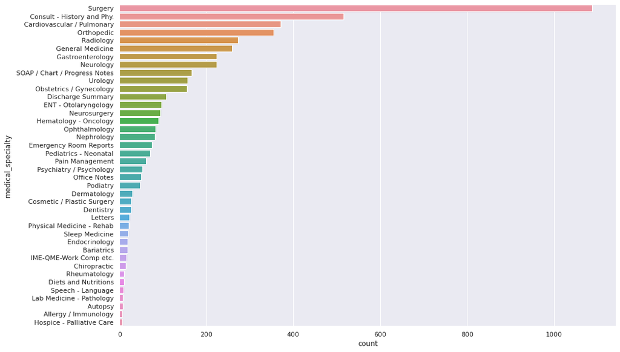

```python
## add patient_id for reference
df['id']=df.index
sns.set(rc={'figure.figsize':(15,10)})
sns.countplot(y='medical_specialty',order=df['medical_specialty'].value_counts().index, data=df)  #df.medical_specialty.value_counts()
```

## Data Sampling for modeling

```python
%%time
nSample=200 ## <specify a number to process the medical terms in a batch>. We recommend 20 for time consideration

df_list_cp, patient_ids_cp = subpopulation_comprehend(df, ' Cardiovascular / Pulmonary',sampleSize=nSample)
df_list_or, patient_ids_or = subpopulation_comprehend(df, ' Orthopedic',sampleSize=nSample)
df_list_ra, patient_ids_ra = subpopulation_comprehend(df, ' Radiology',sampleSize=nSample)
df_list_gm, patient_ids_gm = subpopulation_comprehend(df, ' General Medicine',sampleSize=nSample)
df_list_ga, patient_ids_ga = subpopulation_comprehend(df, ' Gastroenterology',sampleSize=nSample)
df_list_nu, patient_ids_nu = subpopulation_comprehend(df, ' Neurology',sampleSize=nSample)
```

```
original data shape is  (200, 8)
data shape after removing missing entries is  (200, 8)
```

```
original data shape is  (200, 8)
data shape after removing missing entries is  (200, 8)
```

```
original data shape is  (200, 8)
data shape after removing missing entries is  (200, 8)
```

```
original data shape is  (200, 8)
data shape after removing missing entries is  (200, 8)
```

```
original data shape is  (200, 8)
data shape after removing missing entries is  (200, 8)
```

```
original data shape is  (200, 8)
data shape after removing missing entries is  (200, 8)
```

```
CPU times: user 8.7 s, sys: 696 ms, total: 9.39 s
Wall time: 24min 58s
```

### Challenge 1: Do a batch processing using Amazon Comprehend Medical

In this challenge, you are required to write your code within for-loop. You are expected to extract all the medical_conditions for each patient, together with the confidence score

```python
## Function to process a multiple records
def extractMCbatch(transcriptionList,patientIDList):
    df_final = pd.DataFrame()

    if(len(transcriptionList)!=len(patientIDList)):
        return("Error! different length!")

    ## In this for loop, gererate a wide dataframe with extracted medical condition from each item, together with the corresponding ID
    for item,patient_id in zip(transcriptionList,patientIDList):
        print("processing patient_id:",patient_id )

        ###########################################################################
        ## TODO: WRITE YOUR CODE HERE TO GENERATE A ROW FOR THE ITEM FOR THE PATIENT!
        ###########################################################################
        df_ind = extractMC_v2(item)
        df_ind['ID']=patient_id
        df_final=df_final.append(df_ind)

    # remove the duplicated entries if any
    df_final=df_final.sort_values(by=['ID','MEDICAL_CONDITION']).drop_duplicates(['ID','MEDICAL_CONDITION'],keep='last')

    return df_final
```

#### Stucked?

Feel free to check the hint/recording section in [*step 4*](https://www.aiml-loft.wwps.aws.dev/workshops/module-medical-document-processing-and-classification/step2/) on the website

### Test your function *extractMCbatch* and visualize it

[output not shown]

[output cut: 1145 more lines]

[output not shown]

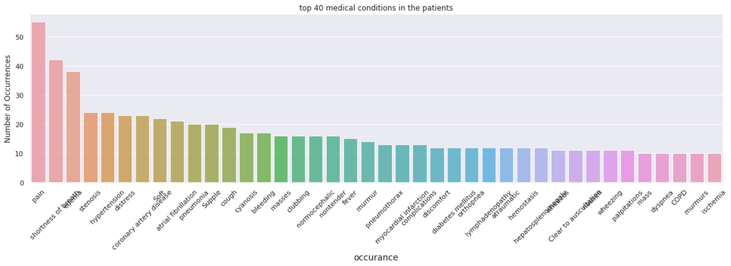

```python
df_extracted_cp=extractMCbatch(df_list_cp,patient_ids_cp)
df_extracted_or=extractMCbatch(df_list_or,patient_ids_or)
df_extracted_ra=extractMCbatch(df_list_ra,patient_ids_ra)
df_extracted_gm=extractMCbatch(df_list_gm,patient_ids_gm)
df_extracted_ga=extractMCbatch(df_list_ga,patient_ids_ga)
df_extracted_nu=extractMCbatch(df_list_nu,patient_ids_nu)

## plot the results
topN=40 ## the number for top conditions
threshold_score=0.8 ##the threshold of confidence score
df_cp_plot=mc_barplot(df_extracted_cp, threshold_score,topN)
```

## Combine the dataset

### Gaps:

After taking a closer look at the dataset, you will observe that the dataset is in long format, meaning that each row represents a single medical condition for one patients. If a patient *John* has 10 medical conditions, there will be 10 rows. Thus, you may expect varied number of rows of each patient.

### Solutions:

In the following cells, function *`retrieve_mcList(df, nFeature=20,threshold=0.9)`* helps to retrieve the features from each subset with `nFeature`(default=20) as specified number of features and `threshold`(default=0.9) as the confidence threshold. Outputs from *`retrieve_mcList()`*:

- top medical conditions list,
- cleaned dataframe through converting to lower case, merg *etc*.

```python
# Extract relavent records
mcListcp, df_grpcp=retrieve_mcList(df_extracted_cp, 40)
mcListor, df_grpor=retrieve_mcList(df_extracted_or, 40)
mcListra, df_grpra=retrieve_mcList(df_extracted_ra, 40)
mcListgm, df_grpgm=retrieve_mcList(df_extracted_gm, 40)
mcListga, df_grpga=retrieve_mcList(df_extracted_ga, 40)
mcListnu, df_grpnu=retrieve_mcList(df_extracted_nu, 40)
```

```python
#df_grpcp['Label']='Cardiovascular / Pulmonary'
#df_grpor['Label']='Orthopedic'
#df_grpra['Label']='Radiology'
#df_grpgm['Label']='General Medicine'
#df_grpga['Label']='Gastroenterology'
#df_grpnu['Label']='Neurology'

df_grpcp['Label']=1
df_grpor['Label']=2
df_grpra['Label']=3
df_grpgm['Label']=4
df_grpga['Label']=5
df_grpnu['Label']=6


df_fulllist = df_grpcp.append([df_grpor, df_grpra, df_grpgm, df_grpga, df_grpnu])
fullmcList=list(set(mcListcp+mcListor+mcListra+mcListgm+mcListga+mcListnu))
df_combined_full=df_mc_generator(df_fulllist, fullmcList ,colname_other=['ID',"Label"] )
```

## Save the processed file

```python
df_combined_full.to_csv("./data/processed_combined_list_6.csv",index=False)

fileUploadPath = os.path.join("./data", "processed_combined_list_6.csv")
boto3.Session().resource("s3").Bucket('hhtestdata').Object("processed_combined_list_6.csv").upload_file(
    fileUploadPath
)
```